# Deaths by horse kicks: Bortkiewicz’s data

This R Notebook is concerned with Ladislaus Bortkiewicz’s investigation of the number of annual deaths by horse kicks in 14 different cavalry corps of the Prussian Army. The dataset can be found [here](http://www.randomservices.org/random/data/HorseKicks.html). Below is the data in tabular form, with $i$ representing the number of deaths in a year and $n_{i}$ the number of occurences:

| $i$ | $n_{i}$ |
| --- | --- |
| 0 | 144 |
| 1 | 91 |
| 2 | 32 |
| 3 | 11 |
| 4 | 2 |
| $\ge 5$ | 0 |

We have 280 observations in total. I will model the annual number of deaths $X_{1}, ..., X_{280}$ as independent Poisson($\lambda$) random variables, with $\lambda$ to be estimated. We can represent the (sorted) data in R as follows:

```r
x <- c(144,91,32,11,2,0)
xobs <- rep(0:5, x)
```

I will now look at the performance of two estimators: the Maximum Likelihood Estimator, $\hat{\lambda}(\mathbf{x}) = \overline{\mathbf{x}}$, and $T$, which is given by:

$$T(\mathbf{x}) = - \text{log}\ p_{0}(\mathbf{x}), \ \ \text{where}
\ \ p_{0}(\mathbf{x}) = \frac{1}{n}\sum_{i=1}^{n} \mathbb{1}_{\{x_{i}=0\}}$$

The indicator function $1_{\{x_{i}=0\}}$ is 1 if $x_{i}=0$ and 0 otherwise. The reasoning for $T$ comes from the fact that $\mathbb{P}(X=0 ; \lambda) = e^{-\lambda}$ for $X \sim \text{Poisson}(\lambda)$.

I will first plot the behaviour of the two estimators in a sampling experiment, using $\lambda = 1$ and $\lambda = 2$. In order to analyze the sampling distribution I will simulate 10000 drawings, each of sample size 280 (like Bortkiewicz’s data), for each $\lambda$.

```r
N <- 10000
# T(X) estimates
samples1 <- sapply(1:N, function(i) -log(mean(rpois(280, lambda=1)==0)))
samples2 <- sapply(1:N, function(i) -log(mean(rpois(280, lambda=2)==0)))
# Maximum likelihood estimates
samples1.mle <- sapply(1:N, function(i) mean(rpois(280, lambda=1)))
samples2.mle <- sapply(1:N, function(i) mean(rpois(280, lambda=2)))
plot(density(samples1), main=expression("Estimators of"~lambda), col='blue',
     xlab=expression(lambda), lty=1, lwd=2, xlim=c(0.6,2.4), ylim=c(0,7))
lines(density(samples2), lty=2, col='blue', lwd=2)
```

```r
lines(density(samples1.mle), lty=1, col='red', lwd=2)
lines(density(samples2.mle), lty=2, col='red', lwd=2)
```

```r
abline(v=1, col='darkgreen')
abline(v=2, col='darkgreen')
```

```r
text(x=1, y=0, label="True value", pos=4, col='darkgreen')
text(x=2, y=0, label="True value", pos=4, col='darkgreen')
```

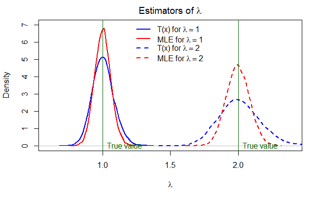

```r
legend('top', legend=c(expression("T(x) for"~lambda==1),
                       expression('MLE for'~lambda==1),
                       expression("T(x) for"~lambda==2),
                       expression('MLE for'~lambda==2)),
       lty=c(1,1,2,2), lwd=rep(2,4), col=c('blue', 'red', 'blue', 'red'), pch=NA, bty='n')
```

The graph shows sampling distributions of $T(\mathbf{X})$ estimates have higher variances than the ML estimates. I will show that the MLE of $\lambda$ is an efficient estimator. For $X \sim \text{Poisson}(\lambda)$ the likelihood and log-likelihood functions are:
$$L(\lambda; x) \propto e^{-\lambda} \frac{\lambda^{x}}{x!}$$
$$\ell(\lambda; x) = -\lambda + x\log(\lambda) + c$$
where $c$ is a constant. The score is given by:
$$\ell^{\ '}(\lambda; x) = -1 + \frac{x}{\lambda}$$
Hence Fisher’s information is:
$$I(\lambda) = \text{Var}( \ell^{\ '}(\lambda; x);\ \lambda) = \frac{1}{\lambda^2}
\text{Var}(X; \lambda) = \frac{1}{\lambda}$$

For $\textbf{X} \overset{iid}{\sim} f_{n}(\cdot;\lambda)$ the MLE of $\lambda$ is $\hat{\lambda} = \overline{\textbf{x}}$. This estimator is unbiased, since:
$$\mathbb{E}(\hat{\lambda}) = \frac{1}{n} \sum_{i=1}^{n}\mathbb{E}(X_{i}; \lambda) =
\lambda$$
by linearity of expectation. Finally, we have:
$$\begin{align*}
\text{Var}(\hat{\lambda};\ \lambda) & = \frac{1}{n^2} \sum_{i=1}^{n} \text{Var}(X_{i};\lambda) \text{ since components of }\mathbf{X}\text{ are iid}\\
\ & = \frac{\lambda}{n}\\
\ & = \frac{1}{nI(\lambda)}
\end{align*}$$

which is the Cramer-Rao lower bound. It follows that $\hat{\lambda}$ is an efficient estimator. Thus, I would prefer the ML estimate over $T(\mathbf{X})$.

The MLE of $\lambda$ for Bortkiewicz’s data is $\overline{\textbf{x}} = 0.7$. This can be confirmed by using R’s $\texttt{optim}$ function:

```r
# Write a function ell which computes the log-likelihood
ell <- function(lambda){
   stopifnot(all(lambda>0))
   -length(xobs)*lambda + sum(xobs)*log(lambda)}
```

I will compute the ML estimate of $\lambda$ by optimizing function $\texttt{ell}$:

```r
ell.optim <- optim(par=0.1, fn=ell, control=list(fnscale=-1), method="L-BFGS-B")
ell.optim
```

```
$par
[1] 0.7000005

$value
[1] -265.9083

$counts
function gradient
       9        9

$convergence
[1] 0

$message
[1] "CONVERGENCE: REL_REDUCTION_OF_F <= FACTR*EPSMCH"
```

This confirms the ML estimate. Using Wald’s approach, I can construct an approximate 95% observed confidence interval $[L(\mathbf{X}), U(\mathbf{X})]$, with:
$$L(\textbf{X}) = \hat{\lambda} - \frac{z_{0.025}}{\sqrt{nI(\hat{\lambda})}}$$
$$U(\textbf{X}) = \hat{\lambda} + \frac{z_{0.025}}{\sqrt{nI(\hat{\lambda})}}$$
where $z_{0.025}$ is the number such that $\mathbb{P}(Z \ge z_{0.025}) = 0.025$, for $Z \sim \mathcal{N}(0,1)$.

```r
lambda.opt <- ell.optim$par
Ihat <- 1/lambda.opt
n <- length(xobs)
L.opt <- lambda.opt - qnorm(1-0.025)/sqrt(n*Ihat)
U.opt <- lambda.opt + qnorm(1-0.025)/sqrt(n*Ihat)
round(c(L=L.opt, U=U.opt), 3)
```

```
    L     U
0.602 0.798
```

Finally, I will plot an asymptotically exact 95% confidence interval using Wilk’s approach. In general, an asymptotically exact 1-$\alpha$ confidence interval is given by:

$$\{ \lambda: 2[\ell(\hat{\lambda}, \mathbf{x}) - \ell(\lambda, \mathbf{x})] \le \chi_{1,\alpha}^2\ \}$$
where $\chi_{1,\alpha}^2$ is the number such that $\mathbb{P}(W \ge \chi_{1,\alpha}^2) = \alpha$, for $W \sim \chi_{1}^2$. In this case, we can approximate a 95% C.I. by:
$$\{ \lambda: \ell(\lambda, \mathbf{x}) \ge \ell(\hat{\lambda}, \mathbf{x}) - 2 \}$$

```r
lambda.mle <- 0.70
lambdas <- seq(from=0.44, to=1.0, length=10001)
# Plot the log-likelihood function
plot(lambdas, ell(lambdas), type='l', lwd=2, main='Log-likelihood function',
     xlab=expression(lambda), ylab="")
# Locate the 95% CI
abline(h=ell(lambda.mle)-2, lty=2, lwd=2, col='red')
```

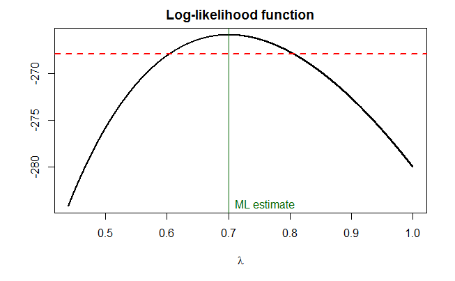

```r
# Plot the ML estimate
abline(v=lambda.mle, col='darkgreen')
text(x=0.7, y=-284, label="ML estimate", pos=4, col='darkgreen')
```

The red dashed line corresponds to $\ell(\hat{\lambda})-2$.